# Herd Sensitivity - Technical Notes

Author

Javier Guitian

## 1 Introduction

These notes explain the epidemiological context and mathematical principles underlying the concept of *Herd Sensitivity*. They have been developed to be used alongside the [*Herd Sensitivity Calculator App*](https://javierguitian.shinyapps.io/herd-sensitivity-calculator/) and cover the principles of sampling without replacement, described by the hypergeometric distribution, together with its binomial approximation. These distributions underpin the **exact** and **approximate** methods to calculate herd sensitivity.

## 2 Concept of Herd Sensitivity

In most veterinary activities involving production animals, the unit of interest is the herd or flock. Decisions regarding the implementation of control measures such as animal movement restrictions, further disease investigations, or culling, are often based on whether the herd, rather than the individual animal, is infected. As a result, surveillance programmes and field investigations usually aim to assess whether a herd or flock contains one or more infected animals. Because animal health surveillance often targets epidemiological units larger than the individual animal, the *World Organization for Animal Health (WOAH) Terrestrial Animal Health Code* defines in Article 1.4.1 [(*Animal Health Surveillance*)](https://www.woah.org/fileadmin/Home/eng/Health_standards/tahc/current/en_chapitre_surveillance_general.htm) the **sensitivity of a surveillance system** as the proportion of infected *sampling units* that are correctly identified as positive, where a sampling unit may be an individual or a group of animals. This definition acknowledges that, for practical and epidemiological reasons, surveillance is frequently implemented at levels other than the individual animal, such as herds, flocks, or other epidemiological units. For this reason, understanding the concept of herd sensitivity is essential for designing and interpreting surveillance activities.

Most infectious diseases tend to cluster or aggregate within herds where animals are in close contact and share the same environmnt and husbandry practices. Herds affected by a given disease will therefore often have more than a single infected animal, and for highly infectious diseases, a large proportion of the herd may be affected. Although complete certainty about a herd’s infection status would require testing all animals, it is usually possible to achieve a high level of confidence by testing only a subset of them.

The **Herd sensitivity** ($HSe$) represents the probability of detecting at least one positive animal if the herd is truly infected.

$HSe = P(\text{at least one animal tests positive} \mid \text{herd is infected}) = 1 - P(\text{all animals test negative} \mid \text{herd is infected})$

It depends on:

- Herd size ($N$)
- Number of animals tested ($n$)
- Test sensitivity ($Se$) and specificity ($Sp$)
- Within-herd prevalence ($p_{wh}$)

In the sections that follow, we will express this relationship formally using probability theory, deriving the expressions for $HSe$ based on the hypergeometric distribution (for sampling without replacement) and showing how the binomial approximation can be applied when appropriate.

## 3 Exact (Hypergeometric) Formulation

The **hypergeometric distribution** describes the probability of obtaining a certain number of “successes” in a sample drawn **without replacement** from a finite population. This mirrors the process of randomly selecting animals from a herd where some may be infected, ensuring that no animal is sampled more than once (i.e. no replacement). The hypergeometric distribution can therefore be used to determine the probability of selecting a given number of infected animals from a herd of known size, for a specified number of animals sampled and an assumed within-herd prevalence of infection.

If we assume a within-herd (design) prevalence ($p\_{wh}$), this represents the expected proportion of infected animals in a herd that is truly infected. For a herd of size ($N$), this corresponds to a fixed number of infected animals: $I = p_{wh} \times N$

Note that for very small herds, some values of the within-herd prevalence may not be feasible. Since the minimum possible number of infected animals in an infected herd is one, the lowest meaningful within-herd prevalence is $1/N$. In practice, if the assumed prevalence corresponds to fewer than one infected animal, calculations should be based on one infected animal.

The probability of selecting exactly ($i$) infected animals when ($n$) are sampled without replacement from a herd of size ($N$) in which ($I$) animals are infected is given by the probability mass function of the hypergeometric distribution:

$$P(X = i) =
\frac{\binom{I}{i}\,\binom{N - I}{\,n - i\,}}{\binom{N}{n}},
\qquad i = 0, 1, \ldots, \min(I, n)$$

In this expression, $\binom{I}{i}$ represents all possible combinations in which $i$ infected animals can be chosen from the $I$ infected animals present in the herd. In other words, it gives the number of distinct subsets of size $i$ that can be formed from the total $I$ infected animals, regardless of order. Each subset corresponds to one possible way in which the sample could include exactly $i$ infected animals. For example, if there are 4 infected animals in a herd (A, B, C, D), there are $\binom{4}{2}=6$ different possible combinations of two infected animals that could be sampled:

(A, B), (A, C), (A, D), (B, C), (B, D), and (C, D).

Similarly, $\binom{N-I}{n-i}$ represents all possible combinations in which $n-i$ uninfected animals can be chosen from the $N-I$ uninfected animals present in the herd. The product of these two terms: $\binom{I}{i}\,\binom{N - I}{\,n - i\,}$ gives the total number of ways to obtain $i$ infected and $n-i$ uninfected animals in a sample of size $n$, randomly obtained from a herd o size $N$ in which $I$ animals are infected.

By dividing this quantity by the total number of possible samples of size $n$ that can be drawn from a herd of size $N$, $\binom{N}{n}$, we obtain the probability that a randomly selected sample of $n$ animals will contain exactly $i$ infected individuals.

## 4 Approximate (Binomial) Formulation

In the previous section we saw how the hypergeometric distribution can be used to determine the probability that a random sample of a certain size contains a specific number of infected animals. A key feature of the hypergeometric distribution is that it assumes sampling without replacement, once an animal has been selected, it cannot be selected again. In practical terms, this means that the effective within-herd prevalence changes slightly with each animal sampled, because the composition of the remaining herd is altered.

The hypergeometric formulation fully accounts for this and therefore provides an exact description of the sampling process. However, the calculations can become computationally intensive, especially for large herds. When herd size increases or when the number of sampled animals represents only a small fraction of the total, the effect of sampling without replacement becomes negligible. Under these conditions, it is reasonable to assume that the probability of selecting an infected animal remains effectively constant from one draw to the next, with each sampled animal having probability $p_{wh}$ of being infected.

This simplification leads to the **binomial approximation**, in which the number of infected animals in a sample of size $n$ is assumed to follow a binomial distribution with parameters $n$ and $p_{wh}$. The probability mass function of the binomial distribution gives the probability of obtaining $X$ “successes” in $n$ independent trials, when the probability of success in a single trial is $p$. In this context, it represents the probability that $i$ animals are infected when $n$ animals are sampled from a herd and each animal has probability $p_{wh}$ of being infected:

This simplification leads to the binomial approximation, in which the number of infected animals in a sample of size $n$ follows a **binomial distribution** with parameters $n$ and $p_{wh}$:

$$P(X = i) \approx \binom{n}{i}\,p_{wh}^{\,i}\,(1 - p_{wh})^{\,n - i},
\qquad i = 0, 1, \ldots, n.$$

The probability that the sample contains at least one infected animal can be obtained as the complement of the probability that no infected animals are included in the sample. The probability of sampling zero infected animals is given by the binomial formula with $i = 0$:

$$P(X = 0) = \binom{n}{0} \, p_{wh}^{\,0} \, (1 - p_{wh})^{\,n - 0} = (1 - p_{wh})^{\,n}$$

Therefore, the probability that the sample contains at least one infected animal is:

$$P(X \ge 1) = 1 - P(X = 0) \approx 1 - (1 - p_{wh})^{\,n}$$

## 5 From Sampling Probabilities to Herd Sensitivity

The probabilities derived in the previous sections describe the likelihood that a random sample of animals from an infected herd contains one or more infected individuals. In practice, animals are not classified as infected or uninfected directly, but according to the result of a diagnostic test with certain sensitivity $Se$ and specificity $Sp$. To obtain the herd sensitivity ($HSe$), i.e. the probability that at least one animal tests positive if the herd is truly infected, we must account for both the sampling process and the performance of the diagnostic test summarized by its sensitivity and specificity.

Once a sample is obtained from an **infected herd**, the probability that all $n$ sampled animals test negative requires that:

- Among the $i$ infected animals in the sample, each yields a negative result with probability $(1 - Se)$.
- Among the $n - i$ uninfected animals in the sample, each yields a negative result with probability $Sp$.

If exactly $i$ infected animals are included among the $n$ sampled, the probability that all sampled animals test negative is:

$$(1 - Se)^{i} \, Sp^{\,n - i}$$

*Exact (hypergeometric) formulation*

Using the hypergeometric sampling probabilities from Section 3, the probability that all sampled animals test negative, given $I$ infected animals in the herd, is:

$$P(\text{all negative} \mid I)
= \sum_{i = 0}^{\min(I, n)}
\frac{\binom{I}{i} \, \binom{N - I}{\,n - i\,}}{\binom{N}{n}} \,
(1 - Se)^{i} \, Sp^{\,n - i}.$$

The above expression calculates, for each possible number of infected animals in the sample ($i = 0, 1, \ldots, \min(I, n)$), the product of two terms: (1) the probability of selecting exactly $i$ infected animals, given by the hypergeometric distribution, and (2) the probability that all $n$ sampled animals test negative, given that $i$ of them are infected and $n - i$ are uninfected. By summing over all possible values of $i$, the expression accounts for every combination of infected and uninfected animals that could occur in the sample and yields the overall probability that all tested animals return negative results, given $I$ infected animals in the herd.

If the within-herd (design) prevalence is $p_{wh}$, we take a fixed number of infected animals $I = p_{wh}N$ (rather than treating $I$ as random). Under this assumption, the herd sensitivity under the exact (hypergeometric) formulation is:

$$HSe_{\text{exact}} = 1 - P(\text{all negative} \mid I = p_{wh} \, N)$$

*Approximate (binomial) formulation*

Under the binomial approximation from Section 4, each draw can be treated as having probability $p_{wh}$ of selecting an infected animal. A sampled animal yields a positive test either because it is infected and tests positive ($Se$), or because it is uninfected and yields a false positive ($1 - Sp$). Thus, the per-animal probability of a positive test ($p_{+}$) is:

$$p_{+} = Se \, p_{wh} + (1 - Sp) \, (1 - p_{wh})$$

Assuming independence across draws, the probability that all $n$ sampled animals test negative is $(1 - p_{+})^{n}$, and therefore:

$$HSe_{\text{approx}} = 1 - (1 - p_{+})^{\,n}
= 1 - \big[ 1 - (Se \, p_{wh} + (1 - Sp)(1 - p_{wh})) \big]^{\,n}$$

In this section, we have shown how herd sensitivity can be calculated by combining the sampling process and the diagnostic test performance, using either the exact (hypergeometric) or the approximate (binomial) formulation. The exact expression accounts for sampling without replacement and a fixed number of infected animals $I = p_{wh} N$, while the approximate expression is accurate when the sampling fraction $n / N$ is small and provides a simple analytical expression based on the per-animal probability of testing positive $p_{+}$. Both formulations describe the same underlying process and yield similar results when $n$ is much smaller than $N$, with the exact version preferred when herd sizes are small or sampling intensity is high. In the final section, we explore how the two approaches compare through a simple illustration implemented in R.

## 6 Illustration and summary

The figure below compares the *exact* (hypergeometric) and *approximate* (binomial) calculations of herd sensitivity across increasing sample sizes.  
The difference between both approaches becomes negligible when the herd is large and the sampling fraction ($n/N$) is small, but can be noticeable for small herds or large sampling fractions.

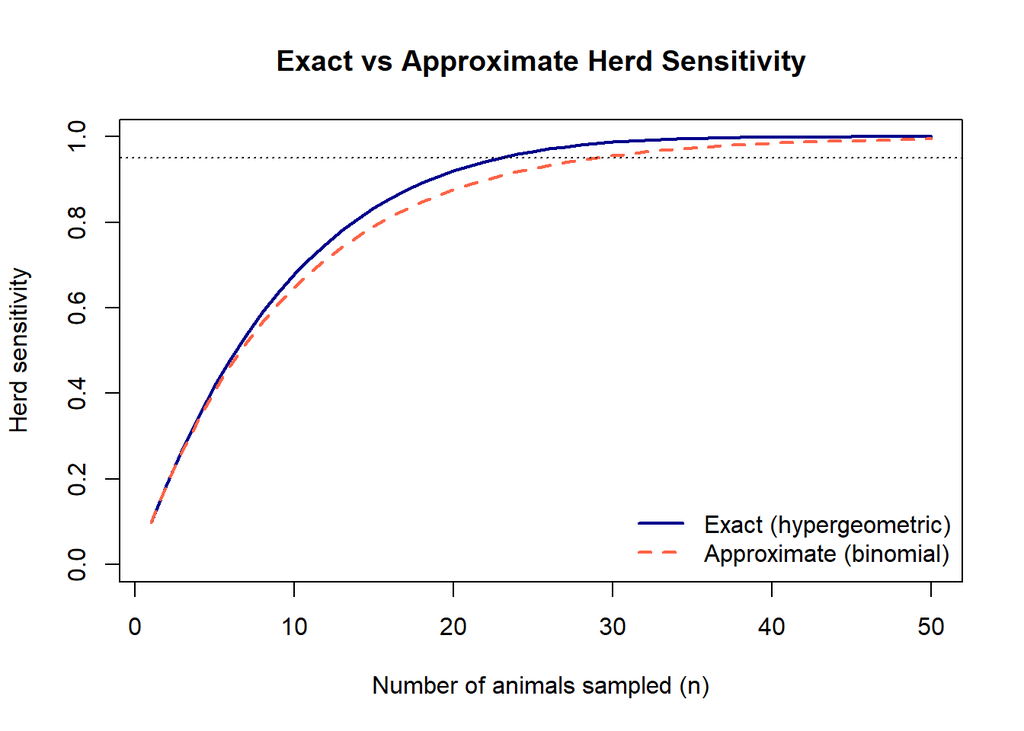

```r
# Parameters
Se <- 0.9
Sp <- 0.99
pwh <- 0.1
N  <- 50                # moderate herd size
n  <- 1:N

# Exact (deterministic I)
herd_sensitivity_exact <- function(Se, Sp, n, N, pwh) {
  n <- min(n, N)
  I <- round(pwh * N)                   # fixed number of infected animals
  i_vals <- 0:min(n, I)
  hg <- dhyper(i_vals, m = I, n = N - I, k = n)
  p_all_neg <- sum(hg * (1 - Se)^i_vals * Sp^(n - i_vals))
  1 - p_all_neg
}

# Approximate (binomial)
herd_sensitivity_approx <- function(Se, Sp, n, pwh) {
  1 - (1 - (Se * pwh + (1 - Sp) * (1 - pwh)))^n
}

# Compute both
HSe_exact  <- sapply(n, herd_sensitivity_exact, Se = Se, Sp = Sp, N = N, pwh = pwh)
HSe_approx <- sapply(n, herd_sensitivity_approx, Se = Se, Sp = Sp, pwh = pwh)

# Plot comparison
plot(n, HSe_exact, type = "l", lwd = 2, col = "darkblue",
     ylim = c(0,1), xlab = "Number of animals sampled (n)",
     ylab = "Herd sensitivity", main = "Exact vs Approximate Herd Sensitivity")
lines(n, HSe_approx, col = "tomato", lwd = 2, lty = 2)
abline(h = 0.95, lty = 3)
legend("bottomright", legend = c("Exact (hypergeometric)", "Approximate (binomial)"),
       col = c("darkblue","tomato"), lwd = 2, lty = c(1,2), bty = "n")
```